# Epigenetic analysis of fetail brain from human monozygotic twins

GO molecular function, GO biological process, MSigDB Pathway and InterPro all show significant enrichment in sensory/olfactory related terms in all 3 cell types.

- Brain

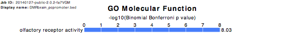

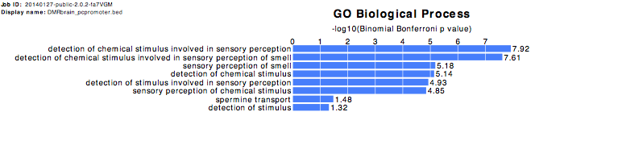

[figure not shown]

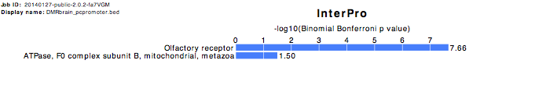

- Cortex

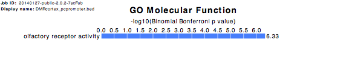

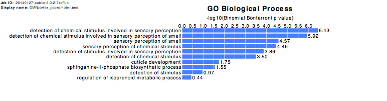

[figure not shown]

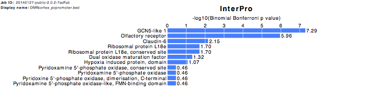

- GE

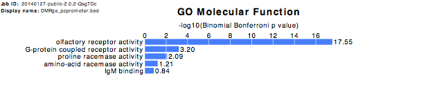

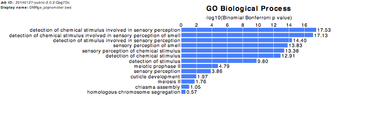

[figure not shown]

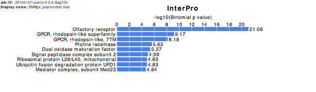

**GREAT annotation on CGI DMRs**

- Brain: enriched in terms related to FGF (fibroblast growth factor) signaling pathway. In brain development, FGF pathway is involved in neurogenesis, axon growth and differentiation and it is a major determinant of neuronal survival.

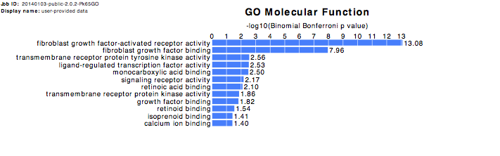

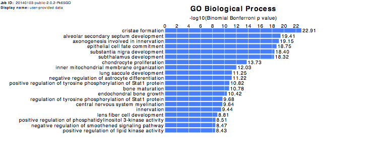

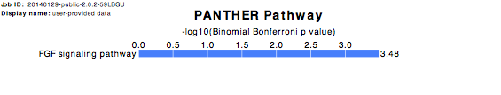

- Cortex: enriched in olfactory processes.

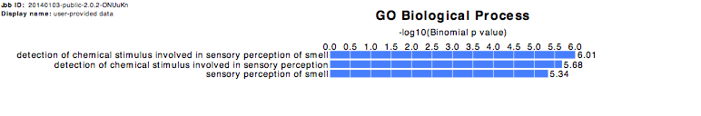

- GE: no enriched terms.

**DAVID annotation on protein-coding genebody DMRs**

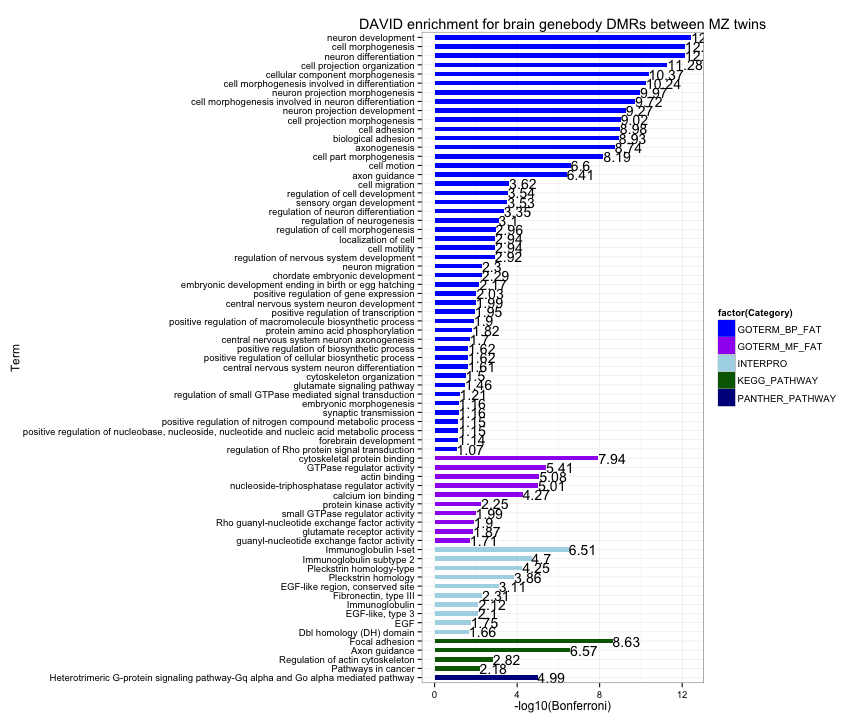

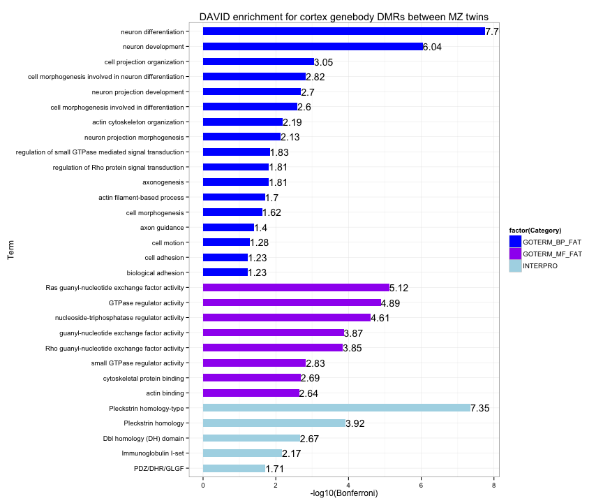